# Analysis of Germany’s Economic Data Synth function outpu commentary

Briefing on Dataset Challenges and Solutions

1. Diverse Data Sources: The dataset combined multiple metrics like inflation, imports, public debt, deficit, and expenditure from varied sources, leading to inconsistencies in terms of years and countries covered.
2. Missing Years: Several years were missing across the datasets, leading to incomplete temporal analysis and potential bias in results.
3. Missing Values for Countries: Some countries had a disproportionate number of missing values, making their inclusion problematic for a consistent comparative analysis.
4. Remedial Actions:

Country Exclusion: Specific countries like Estonia, Slovenia, Latvia, Lithuania, Luxemburg, and Belgium were removed due to excessive missing data, ensuring a more consistent dataset.

Matching by Common Years: To ensure consistency across metrics, the data was matched based on common years available in all datasets, removing outliers in time.

Interpolation for Missing Values: For years where data was still missing after the above steps, interpolation was used to estimate values based on existing data points. This helped fill gaps without introducing significant bias.

## Loading Libraries

We start by importing the necessary packages: - `tidyverse` is a comprehensive package used for data manipulation and visualization. - `readxl` allows us to read in Excel files with ease.

## Define Countries to be Removed

Next, a list of countries that we wish to exclude from our analysis is defined. The countries in this list are: Estonia, Slovenia, Latvia, Lithuania, Luxemburg, and Belgium.

## File Path

The path to our primary data source, the Excel file named “GER_clean.xlsx”, is specified. This file contains various economic indicators across different countries and years.

## Function Definition

To streamline our data cleaning and processing, a function named `read_and_process` is defined. This function does two main things: 1. Reads data from a specified sheet of our Excel file. 2. Excludes countries from our predefined removal list.

## Reading Individual Sheets

Using the function defined above, data from each sheet in the Excel file (`Inflation`, `Imports`, `Public Debt`, `Deficit`, and `Expenditure`) is read and processed. The data from each sheet is stored in its respective variable.

## Transforming Data from Wide to Long Format

For easier merging and analysis, the datasets are transformed from a wide format (with years as columns) to a long format. In this long format, each row represents data for a specific country and year. This transformation is done for each of the datasets individually.

## Identify Common Years

It’s essential that our merged dataset is consistent. To achieve this, we identify years that are common across all the individual datasets. This ensures that we only include data in our final dataset for years that have information available across all economic indicators.

## Filter by Common Years

After identifying the common years, each dataset is filtered to only include data corresponding to these years.

## Merging Datasets

The individual datasets are then combined into a single comprehensive dataset. This final dataset includes all the economic indicators (`Inflation`, `Imports`, `Public Debt`, `Deficit`, and `Expenditure`) for each country and year.

## Output

The resultant dataset, named `long_data`, is displayed. Each row of this dataset provides a snapshot of the economic indicators for a specific country in a particular year.

```r
# Load required libraries
library(tidyverse)
library(readxl)

# Define a vector of countries to be removed
countries_to_remove <- c("Estonia", "Slovenia", "Latvia", "Lithuania", "Luxemburg", "Belgium")

# Updated file path
file_path <- "C:\\Users\\gabu\\Documents\\Germany\\GER_clean.xlsx"

# Read the data and remove specified countries
read_and_process <- function(file_path, sheet_name) {
  read_excel(file_path, sheet = sheet_name) %>%
    filter(!(`Country Code` %in% countries_to_remove))
}

# Read and process data from each sheet
inflation_data <- read_and_process(file_path, "Inflation")
Imports_data <- read_and_process(file_path, "Imports")
public_debt_data <- read_and_process(file_path, "Public Debt")
deficit_data <- read_and_process(file_path, "Deficit")
expenditure_data <- read_and_process(file_path, "Expenditure")

# Transform data from wide to long format
long_inflation <- inflation_data %>%
  gather(key = "Year", value = "Inflation", -`Country Code`) %>%
  rename(Country = `Country Code`) %>%
  mutate(Inflation = round(Inflation, 2))

long_imports <- Imports_data %>%
  gather(key = "Year", value = "Imports", -`Country Code`) %>%
  rename(Country = `Country Code`)

long_public_debt <- public_debt_data %>%
  gather(key = "Year", value = "Public Debt", -`Country Code`) %>%
  rename(Country = `Country Code`)

long_deficit <- deficit_data %>%
  gather(key = "Year", value = "Deficit", -`Country Code`) %>%
  rename(Country = `Country Code`)

long_expenditure <- expenditure_data %>%
  gather(key = "Year", value = "Expenditure", -`Country Code`) %>%
  rename(Country = `Country Code`)

# Get the common years across all datasets
common_years <- intersect(intersect(intersect(intersect(
  unique(long_inflation$Year),
  unique(long_imports$Year)),
  unique(long_public_debt$Year)),
  unique(long_deficit$Year)),
  unique(long_expenditure$Year))

# Filter each dataset to only include rows with those years
long_inflation <- long_inflation %>% filter(Year %in% common_years)
long_imports <- long_imports %>% filter(Year %in% common_years)
long_public_debt <- long_public_debt %>% filter(Year %in% common_years)
long_deficit <- long_deficit %>% filter(Year %in% common_years)
long_expenditure <- long_expenditure %>% filter(Year %in% common_years)

# Merge all datasets based on Country and Year
long_data <- left_join(long_inflation, long_imports, by = c("Country", "Year"))
long_data <- left_join(long_data, long_public_debt, by = c("Country", "Year"))
long_data <- left_join(long_data, long_deficit, by = c("Country", "Year"))
long_data <- left_join(long_data, long_expenditure, by = c("Country", "Year"))

# View the transformed data
print(long_data)
```

| Country | Year | Inflation | Imports | Public Debt | Deficit | Expenditure |
| --- | --- | --- | --- | --- | --- | --- |
| Austria | 1973.0 | 7.53 | 27.5374528314848 | 55.21452 | -0.83059495 | 27.61209 |
| Finland | 1973.0 | 10.75 | 24.9034829556605 | 84.68000 | 4.35827668 | 19.87229 |
| France | 1973.0 | 7.38 | 16.881250174099556 | 109.44627 | 1.59672499 | 29.34407 |
| Germany | 1973.0 | 7.03 | 16.34794912516145 | 100.51652 | 1.52717495 | 20.58587 |
| Greece | 1973.0 | 15.38 | 20.092861688914887 | 39.26195 | -1.96147755 | 15.80969 |
| Ireland | 1973.0 | NA | 41.21625524952727 | 78.19687 | -2.12851439 | 28.65308 |
| Italy | 1973.0 | 10.80 | 17.959219962779418 | 72.98684 | -4.05517220 | 26.62007 |
| Netherlands | 1973.0 | 8.02 | 40.74562579581782 | 77.51975 | 2.28041824 | 34.92824 |
| Portugal | 1973.0 | 12.97 | 26.296722540821943 | 119.61389 | NA | NA |
| Spain | 1973.0 | 11.42 | 14.7856018915624 | 79.45359 | 0.41683057 | 16.19310 |

[output cut: 480 more lines]

```r
NA
NA
NA
NA
NA
NA
```

```r
# Convert the 'Year' column to numeric type
long_data$Year <- as.numeric(long_data$Year)
long_data$Imports <- as.numeric(long_data$Imports)
long_data$`Public Debt` <- as.numeric(long_data$`Public Debt`)
long_data$Deficit <- as.numeric(long_data$Deficit)
long_data$Expenditure <- as.numeric(long_data$Expenditure)



# View the cleaned data
print(long_data)
```

| Country | Year | Inflation | Imports | Public Debt | Deficit | Expenditure |
| --- | --- | --- | --- | --- | --- | --- |
| Austria | 1973 | 7.53 | 27.53745 | 55.21452 | -0.83059495 | 27.61209 |
| Finland | 1973 | 10.75 | 24.90348 | 84.68000 | 4.35827668 | 19.87229 |
| France | 1973 | 7.38 | 16.88125 | 109.44627 | 1.59672499 | 29.34407 |
| Germany | 1973 | 7.03 | 16.34795 | 100.51652 | 1.52717495 | 20.58587 |
| Greece | 1973 | 15.38 | 20.09286 | 39.26195 | -1.96147755 | 15.80969 |
| Ireland | 1973 | NA | 41.21626 | 78.19687 | -2.12851439 | 28.65308 |
| Italy | 1973 | 10.80 | 17.95922 | 72.98684 | -4.05517220 | 26.62007 |
| Netherlands | 1973 | 8.02 | 40.74563 | 77.51975 | 2.28041824 | 34.92824 |
| Portugal | 1973 | 12.97 | 26.29672 | 119.61389 | NA | NA |
| Spain | 1973 | 11.42 | 14.78560 | 79.45359 | 0.41683057 | 16.19310 |

[output cut: 480 more lines]

```r
NA
```

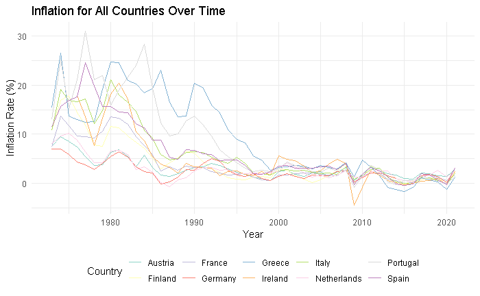

```r
library(ggplot2)

# Plotting inflation for all countries
ggplot(long_data, aes(x = Year, y = Inflation, color = Country)) +
  geom_line() +
  theme_minimal() +
  labs(title = "Inflation for All Countries Over Time",
       x = "Year",
       y = "Inflation Rate (%)",
       color = "Country") +
  theme(legend.position="bottom") +
  scale_color_brewer(palette="Set3")
```

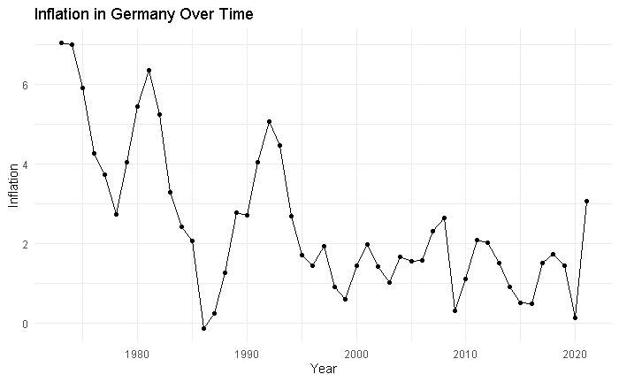

```r
# Filter data for Germany only
germany_data <- long_data %>% filter(Country == "Germany")

# Plotting Inflation for Germany
ggplot(germany_data, aes(x = Year, y = Inflation)) +
  geom_line() +
  theme_minimal() +
  labs(title = "Inflation in Germany Over Time", x = "Year", y = "Inflation") +
  geom_point()
```

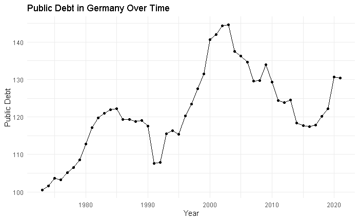

```r
# Plotting Public Debt for Germany
ggplot(germany_data, aes(x = Year, y = `Public Debt`)) +
  geom_line() +
  theme_minimal() +
  labs(title = "Public Debt in Germany Over Time", x = "Year", y = "Public Debt") +
  geom_point()
```

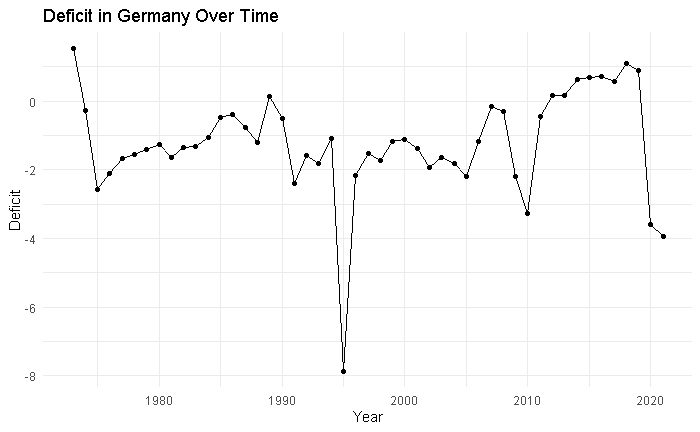

```r
# Plotting Deficit for Germany
ggplot(germany_data, aes(x = Year, y = Deficit)) +
  geom_line() +
  theme_minimal() +
  labs(title = "Deficit in Germany Over Time", x = "Year", y = "Deficit") +
  geom_point()
```

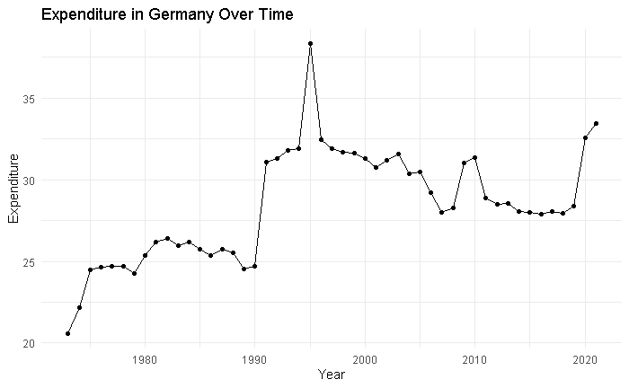

```r
# Plotting Expenditure for Germany
ggplot(germany_data, aes(x = Year, y = Expenditure)) +
  geom_line() +
  theme_minimal() +
  labs(title = "Expenditure in Germany Over Time", x = "Year", y = "Expenditure") +
  geom_point()
```

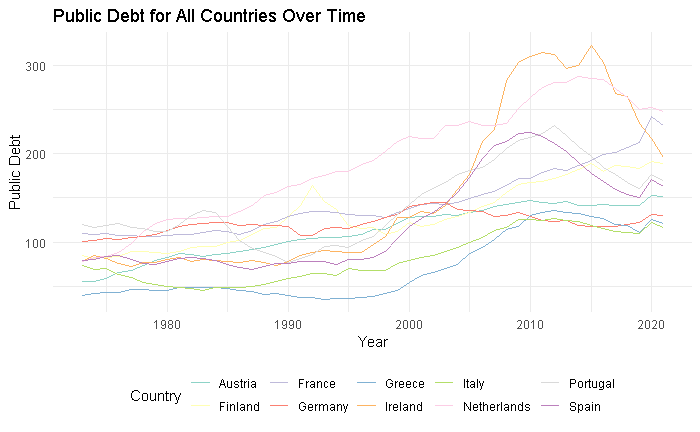

```r
# Plotting public debt for all countries over time
ggplot(long_data, aes(x = Year, y = `Public Debt`, color = Country)) +
  geom_line() +
  theme_minimal() +
  labs(title = "Public Debt for All Countries Over Time",
       x = "Year",
       y = "Public Debt",
       color = "Country") +
  theme(legend.position="bottom") +
  scale_color_brewer(palette="Set3")
```

```r
#transform to numeric
#mapping country to numeric and country name
#arrange by country


long_data$CountryNumeric <- as.numeric(as.factor(long_data$Country))

# Check the mapping between Country and Country_ID
country_mapping <- unique(long_data[, c("Country", "CountryNumeric")])


long_data <- long_data %>%
  arrange(Country, Year)



print(country_mapping)
```

| Country | CountryNumeric |
| --- | --- |
| Austria | 1 |
| Finland | 2 |
| France | 3 |
| Germany | 4 |
| Greece | 5 |
| Ireland | 6 |
| Italy | 7 |
| Netherlands | 8 |
| Portugal | 9 |
| Spain | 10 |

```r
print (long_data)
```

| Country | Year | Inflation | Imports | Public Debt | Deficit | Expenditure | CountryNumeric |
| --- | --- | --- | --- | --- | --- | --- | --- |
| Austria | 1973 | 7.53 | 27.53745 | 55.21452 | -0.83059495 | 27.61209 | 1 |
| Austria | 1974 | 9.52 | 30.45336 | 55.52718 | -0.49562294 | 27.90388 | 1 |
| Austria | 1975 | 8.45 | 28.50450 | 59.19173 | -3.24070526 | 31.10848 | 1 |
| Austria | 1976 | 7.32 | 31.16376 | 65.21788 | -3.63189512 | 31.61916 | 1 |
| Austria | 1977 | 5.49 | 32.32364 | 67.71869 | -2.99205676 | 31.41366 | 1 |
| Austria | 1978 | 3.57 | 30.55289 | 73.78815 | -3.00196643 | 33.85175 | 1 |
| Austria | 1979 | 3.71 | 32.43644 | 78.73861 | -2.61026998 | 33.32242 | 1 |
| Austria | 1980 | 6.33 | 35.13193 | 82.72654 | -2.28045171 | 33.47394 | 1 |
| Austria | 1981 | 6.80 | 35.39589 | 86.49293 | -2.25138567 | 34.56544 | 1 |
| Austria | 1982 | 5.44 | 32.37562 | 85.57855 | -3.74138547 | 34.99664 | 1 |

[output cut: 480 more lines]

```r
#check the countries in the pool

country_vector <- setNames(object = country_mapping$CountryNumeric, nm = country_mapping$Country)

print (country_vector)
```

```
    Austria     Finland      France     Germany      Greece     Ireland       Italy Netherlands
          1           2           3           4           5           6           7           8
   Portugal       Spain
          9          10
```

The code uses the `tidyverse` package to address missing values in the `long_data` dataset.

1. It groups the data by `Country` to ensure interpolations are done within each nation’s data.
2. The `approx` function performs linear interpolation, filling missing values for metrics like Inflation, Imports, etc., based on surrounding known points.
3. The data is then ungrouped and displayed.

**Purpose**: This interpolation is essential to provide a continuous dataset, which facilitates better analysis and visualization by filling gaps based on the linear relationship of known data points.

```r
library(tidyverse)

# Linear interpolation for missing values
long_data <- long_data %>%
  group_by(Country) %>%
  mutate(
    Inflation = ifelse(is.na(Inflation), approx(Year, Inflation, Year, rule = 2)$y, Inflation),
    Imports = ifelse(is.na(Imports), approx(Year, Imports, Year, rule = 2)$y, Imports),
    `Public Debt` = ifelse(is.na(`Public Debt`), approx(Year, `Public Debt`, Year, rule = 2)$y, `Public Debt`),
    Deficit = ifelse(is.na(Deficit), approx(Year, Deficit, Year, rule = 2)$y, Deficit),
    Expenditure = ifelse(is.na(Expenditure), approx(Year, Expenditure, Year, rule = 2)$y, Expenditure)
  ) %>%
  ungroup()

# Check the resulting dataframe
print(long_data)
```

| Country | Year | Inflation | Imports | Public Debt | Deficit | Expenditure | CountryNumeric |
| --- | --- | --- | --- | --- | --- | --- | --- |
| Austria | 1973 | 7.53 | 27.53745 | 55.21452 | -0.83059495 | 27.61209 | 1 |
| Austria | 1974 | 9.52 | 30.45336 | 55.52718 | -0.49562294 | 27.90388 | 1 |
| Austria | 1975 | 8.45 | 28.50450 | 59.19173 | -3.24070526 | 31.10848 | 1 |
| Austria | 1976 | 7.32 | 31.16376 | 65.21788 | -3.63189512 | 31.61916 | 1 |
| Austria | 1977 | 5.49 | 32.32364 | 67.71869 | -2.99205676 | 31.41366 | 1 |
| Austria | 1978 | 3.57 | 30.55289 | 73.78815 | -3.00196643 | 33.85175 | 1 |
| Austria | 1979 | 3.71 | 32.43644 | 78.73861 | -2.61026998 | 33.32242 | 1 |
| Austria | 1980 | 6.33 | 35.13193 | 82.72654 | -2.28045171 | 33.47394 | 1 |
| Austria | 1981 | 6.80 | 35.39589 | 86.49293 | -2.25138567 | 34.56544 | 1 |
| Austria | 1982 | 5.44 | 32.37562 | 85.57855 | -3.74138547 | 34.99664 | 1 |

[output cut: 480 more lines]

```r
NA
```

```r
#working Synth Function

# Load library

library(Synth)
long_data <- as.data.frame(long_data)



# Create the named vector from country_mapping dataframe
country_vector <- setNames(object = country_mapping$CountryNumeric, nm = country_mapping$Country)



# Prepare the data for the Synth function using the named vector
dataprep.out <- dataprep(
  foo = long_data,
  predictors = c("Deficit", "Expenditure", "Public Debt"),
  dependent = "Inflation",
  unit.variable = "CountryNumeric",
  time.variable = "Year",
  special.predictors = list(
    list("Inflation", 1980:2011, "mean"),
    list("Deficit", 1980:2011, "mean"),
    list("Public Debt", 1980:2011, "mean"),
    list("Expenditure", 1980:2011, "mean")
  ),
  treatment.identifier = country_vector["Germany"],  # Germany's numeric ID
  controls.identifier = country_vector[names(country_vector) != "Germany"],  # Numeric IDs of countries other than Germany
  time.predictors.prior = 1980:2011,
  time.optimize.ssr = 1980:2020,
  time.plot = 1980:2020,
  unit.names.variable = "Country"
)
```

```r
# Load the necessary library
library(Synth)

# Compute the synthetic control using the dataprep output
synth.out <- synth(data.prep.obj = dataprep.out)
```

```
X1, X0, Z1, Z0 all come directly from dataprep object.


****************
 searching for synthetic control unit


****************
****************
****************

MSPE (LOSS V): 1.699446

solution.v:
 0.2100359 1.912e-07 0.3050237 0.3577269 0.03721887 0.08998928 5.0914e-06

solution.w:
 0.4703317 0.4232437 2.489e-07 2.33e-08 1.328e-07 1.098e-07 0.1064239 4.47e-08 9.55e-08
```

```r
# Create synthetic tables to summarize the results
synth.tables <- synth.tab(
  dataprep.res = dataprep.out,
  synth.res = synth.out
)

# Display the synthetic tables
print(synth.tables)
```

```
$tab.pred
                              Treated Synthetic Sample Mean
Deficit                        -1.527    -1.856      -4.470
Expenditure                    29.261    38.547      39.028
Public Debt                   125.032   125.633     119.948
special.Inflation.1980.2011     2.301     3.069       5.261
special.Deficit.1980.2011      -1.527    -1.856      -4.470
special.Public Debt.1980.2011 125.032   125.633     119.948
special.Expenditure.1980.2011  29.261    38.547      39.028

$tab.v
                              v.weights
Deficit                       0.21
Expenditure                   0
Public Debt                   0.305
special.Inflation.1980.2011   0.358
special.Deficit.1980.2011     0.037
special.Public Debt.1980.2011 0.09
special.Expenditure.1980.2011 0

$tab.w
   w.weights  unit.names unit.numbers
1      0.470     Austria            1
2      0.423     Finland            2
3      0.000      France            3
5      0.000      Greece            5
6      0.000     Ireland            6
7      0.000       Italy            7
8      0.106 Netherlands            8
9      0.000    Portugal            9
10     0.000       Spain           10

$tab.loss
         Loss W   Loss V
[1,] 0.03154519 1.699446
```

Overview:

The output details the results from a Synthetic Control Method (SCM) analysis. The goal of SCM is to create a synthetic control (or a weighted combination of control units) that best approximates the characteristics of a treated unit in the pre-treatment period. The idea is to then use this synthetic control to predict the outcome of the treated unit in the post-treatment period if it had not been treated.

Findings:

Predictor Weights (solution.v):

The weights (v.weights) assigned to each predictor when constructing the synthetic control are:

Deficit: 21% Expenditure: 0% (suggesting it wasn’t deemed important for constructing the synthetic control in this instance) Public Debt: 30.5% special.Inflation.1980.2011: 35.8% special.Deficit.1980.2011: 3.7% special.Public Debt.1980.2011: 9% special.Expenditure.1980.2011: 0% The weights reveal which predictors are most influential in constructing the synthetic control. Here, special.Inflation.1980.2011 is the most influential predictor followed by Public Debt.

Synthetic Control Weights (solution.w):

The weights show how each control unit contributes to the formation of the synthetic control:

Austria: 47% Finland: 42.3% Netherlands: 10.6% Other countries like France, Greece, Ireland, Italy, Portugal, and Spain have zero or negligible weights, implying they do not contribute to the synthetic control for Germany.

This suggests that the economic behaviors of Austria, Finland, and the Netherlands (in the specified predictors) most closely resemble that of Germany in the pre-treatment period.

Predicted Values (tab.pred):

For each variable, we have values for the Treated unit (Germany), the Synthetic control, and the Sample Mean:

For Deficit, the synthetic control predicts a value of -1.856 compared to Germany’s actual value of -1.527. Expenditure is predicted at 38.547 compared to Germany’s 29.261. Similarly, other variables can be compared. The closer the synthetic values are to Germany’s actual values in the pre-treatment period, the better the synthetic control approximates Germany.

Mean Squared Prediction Errors (MSPE):

The MSPE (LOSS V) is 1.699446. This is a measure of the difference between the actual values of Germany and the synthetic control’s predictions in the pre-treatment period. A lower MSPE indicates a good fit of the synthetic control.

Losses (tab.loss):

Loss in W and V are metrics to evaluate the goodness of fit of the synthetic control. They are measures of how well the synthetic control approximates the treated unit in the pre-treatment period. In this case, the Loss W is 0.03154519, and the Loss V is 1.699446.

Conclusion:

The SCM analysis has provided a synthetic control for Germany using a combination of Austria, Finland, and the Netherlands. The chosen predictors and their weights show which economic indicators were deemed most important for this approximation. The MSPE and loss values can be used to assess the accuracy of the synthetic control in replicating Germany’s economic behavior in the pre-treatment period. The results can be used to make post-treatment predictions and infer causal effects.

```r
# Inspect the structure of the synth output
str(synth.out)
```

```
List of 6
 $ solution.v:'data.frame': 1 obs. of  7 variables:
  ..$ Deficit                      : num 0.21
  ..$ Expenditure                  : num 1.91e-07
  ..$ Public.Debt                  : num 0.305
  ..$ special.Inflation.1980.2011  : num 0.358
  ..$ special.Deficit.1980.2011    : num 0.0372
  ..$ special.Public Debt.1980.2011: num 0.09
  ..$ special.Expenditure.1980.2011: num 5.09e-06
 $ solution.w: num [1:9, 1] 4.70e-01 4.23e-01 2.49e-07 2.33e-08 1.33e-07 ...
  ..- attr(*, "dimnames")=List of 2
  .. ..$ : chr [1:9] "1" "2" "3" "5" ...
  .. ..$ : chr "w.weight"
 $ loss.v    : num [1, 1] 1.7
  ..- attr(*, "dimnames")=List of 2
  .. ..$ : chr "4"
  .. ..$ : chr "4"
 $ loss.w    : num [1, 1] 0.0315
  ..- attr(*, "dimnames")=List of 2
  .. ..$ : chr "w.weight"
  .. ..$ : chr "w.weight"
 $ custom.v  : NULL
 $ rgV.optim :List of 3
  ..$ out.list:Classes ‘optimx’ and 'data.frame':   2 obs. of  15 variables:
  .. ..$ p1      : num [1:2] 0.214 -0.0294
  .. ..$ p2      : num [1:2] -1.95e-07 -9.17e-01
  .. ..$ p3      : num [1:2] 0.311 0.227
  .. ..$ p4      : num [1:2] 0.365 2.526
  .. ..$ p5      : num [1:2] -0.0379 -0.0294
  .. ..$ p6      : num [1:2] 0.0917 0.2273
  .. ..$ p7      : num [1:2] -5.19e-06 -9.17e-01
  .. ..$ value   : num [1:2] 1.7 5.64
  .. ..$ fevals  : num [1:2] 502 14
  .. ..$ gevals  : num [1:2] NA 8
  .. ..$ niter   : num [1:2] NA NA
  .. ..$ convcode: num [1:2] 1 0
  .. ..$ kkt1    : logi [1:2] NA NA
  .. ..$ kkt2    : logi [1:2] NA NA
  .. ..$ xtime   : num [1:2] 2.81 0.61
  .. ..- attr(*, "details")=List of 10
```

[output cut: 23 more lines]

```
  .. ..$ p6: num 0.0917
  .. ..$ p7: num -5.19e-06
  .. ..- attr(*, "details")=List of 5
  .. .. ..$ : chr "Nelder-Mead"
  .. .. ..$ : logi NA
  .. .. ..$ : logi NA
  .. .. ..$ : logi NA
  .. .. ..$ : chr "none"
  .. .. ..- attr(*, "dim")= int [1:2] 1 5
  .. .. ..- attr(*, "dimnames")=List of 2
  .. .. .. ..$ : chr "Nelder-Mead"
  .. .. .. ..$ : chr [1:5] "method" "ngatend" "nhatend" "hev" ...
  .. ..- attr(*, "maximize")= logi FALSE
  .. ..- attr(*, "npar")= int 7
  ..$ value   : num 1.7
```

```r
# Assuming the synthetic control data can be accessed, extract it
# This is a hypothetical example; you'll need to adjust based on the actual structure
synthetic_data <- synth.out$synthetic_control_component  # Replace with the actual component name

# Subset to get data after 2011
#synthetic_data_post_2011 <- subset(synthetic_data, Year > 2011)

# View the synthetic data post-2011
print(synthetic_data_post_2011)
```

[output not shown]

```r
# Assuming long_data is your dataset
# with columns 'Year', 'Country', and 'Inflation'

# Define the weights for the control countries
weights <- c(Austria = 0.4703317, Finland = 0.4232437, France = 2.489e-07,
             Greece = 2.33e-08, Ireland = 1.328e-07, Italy = 1.097877e-07,
             Netherlands = 0.1064239, Portugal = 4.47e-08, Spain = 9.545591e-08)

# Filter out Germany and select only control countries
control_data <- subset(long_data, Country %in% names(weights))

# Initialize a dataframe for synthetic Germany data
synthetic_germany <- data.frame(Year = unique(control_data$Year), Inflation = NA)

# Calculate the synthetic data for each year
for (year in synthetic_germany$Year) {
    year_data <- subset(control_data, Year == year)
    # Ensure that countries in year_data are in the same order as in the weights vector
    year_data <- year_data[match(names(weights), year_data$Country),]
    weighted_avg <- sum(year_data$Inflation * weights, na.rm = TRUE)
    synthetic_germany[synthetic_germany$Year == year, "Inflation"] <- weighted_avg
}

# View the synthetic Germany data
print(synthetic_germany)
```

| Year | Inflation |
| --- | --- |
| 1973 | 8.9449946 |
| 1974 | 12.6679224 |
| 1975 | 12.5999352 |
| 1976 | 10.4518753 |
| 1977 | 8.2532873 |
| 1978 | 5.4177950 |
| 1979 | 5.3535504 |
| 1980 | 8.5754246 |
| 1981 | 8.7024497 |
| 1982 | 7.2422542 |

[output cut: 39 more lines]

```r
NA
NA
NA
NA
NA
```

```r
#the weight of the countries
print (weights)
```

```
     Austria      Finland       France       Greece      Ireland        Italy  Netherlands
4.703317e-01 4.232437e-01 2.489000e-07 2.330000e-08 1.328000e-07 1.097877e-07 1.064239e-01
    Portugal        Spain
4.470000e-08 9.545591e-08
```

```r
# Assuming you have a dataframe for actual Germany data
germany_data <- subset(long_data, Country == "Germany", select = c("Year", "Inflation"))

# Merge Germany's actual data with synthetic Germany data
did_data <- merge(germany_data, synthetic_germany, by = "Year", suffixes = c("_Actual", "_Synthetic"))



# Add the posttreatment variable (1 if year >= 2011, 0 otherwise)
did_data$posttreatment <- ifelse(did_data$Year >= 2011, 1, 0)

# Create an indicator variable for actual Germany (always 1 in this case)
did_data$ActualGermany <- 1

print (did_data)
```

| Year | Inflation_Actual | Inflation_Synthetic | posttreatment | ActualGermany |
| --- | --- | --- | --- | --- |
| 1973 | 7.03 | 8.9449946 | 0 | 1 |
| 1974 | 6.99 | 12.6679224 | 0 | 1 |
| 1975 | 5.91 | 12.5999352 | 0 | 1 |
| 1976 | 4.25 | 10.4518753 | 0 | 1 |
| 1977 | 3.73 | 8.2532873 | 0 | 1 |
| 1978 | 2.72 | 5.4177950 | 0 | 1 |
| 1979 | 4.04 | 5.3535504 | 0 | 1 |
| 1980 | 5.44 | 8.5754246 | 0 | 1 |
| 1981 | 6.34 | 8.7024497 | 0 | 1 |
| 1982 | 5.24 | 7.2422542 | 0 | 1 |

[output cut: 39 more lines]

```r
# Conduct the DiD analysis
did_model <- lm(Inflation_Actual ~ Inflation_Synthetic * posttreatment, data = did_data)

# View the summary of the model
summary(did_model)
```

```
Call:
lm(formula = Inflation_Actual ~ Inflation_Synthetic * posttreatment,
    data = did_data)

Residuals:
    Min      1Q  Median      3Q     Max
-1.8822 -0.6105 -0.0698  0.3680  2.6138

Coefficients:
                                  Estimate Std. Error t value Pr(>|t|)
(Intercept)                        0.74331    0.25183   2.952  0.00501 **
Inflation_Synthetic                0.49145    0.04755  10.335 1.83e-13 ***
posttreatment                     -0.66539    0.67810  -0.981  0.33171
Inflation_Synthetic:posttreatment  0.32192    0.34772   0.926  0.35947
---
Signif. codes:  0 ‘***’ 0.001 ‘**’ 0.01 ‘*’ 0.05 ‘.’ 0.1 ‘ ’ 1

Residual standard error: 0.9552 on 45 degrees of freedom
Multiple R-squared:  0.7437,    Adjusted R-squared:  0.7266
F-statistic: 43.53 on 3 and 45 DF,  p-value: 2.348e-13
```

Post-treatment Inflation Decrease (posttreatment Coefficient):

The negative coefficient for posttreatment (-0.66539) suggests a decrease in Germany’s actual inflation rate in the post-treatment period compared to the pre-treatment period. However, this finding is not statistically significant (p-value = 0.33171), indicating that the evidence for this decrease is not strong. Therefore, while the model suggests a decrease, this result should be interpreted with caution due to its lack of statistical significance. Strong Correlation between Synthetic and Actual Inflation (Inflation_Synthetic Coefficient):

The positive and highly significant coefficient for Inflation_Synthetic (0.49145) indicates a strong and statistically significant correlation between the synthetic inflation rate and Germany’s actual inflation rate. This implies that the synthetic control, constructed as a weighted average of control countries, is a good predictor of Germany’s actual inflation rate. It validates the use of the synthetic control method in approximating Germany’s counterfactual scenario. Change in the Gap in the Post-treatment Period (Inflation_Synthetic:posttreatment Interaction Term):

The interaction term Inflation_Synthetic:posttreatment (0.32192) suggests a change in the relationship between the synthetic and actual inflation rates in the post-treatment period. A positive coefficient indicates that this gap might have increased post-treatment. However, like the posttreatment coefficient, this interaction term is also not statistically significant (p-value = 0.35947). The lack of significance means there isn’t strong evidence to conclusively say that the treatment had a differential impact on the gap between the actual and synthetic inflation rates. In summary, while the model indicates a decrease in actual inflation and a potential change in the gap between actual and synthetic inflation post-treatment, the lack of statistical significance for these changes suggests that these findings are not robust. The model does provide strong evidence of a correlation between synthetic and actual inflation rates, supporting the validity of the synthetic control method. However, the exact impact of the treatment remains unclear due to the non-significant post-treatment effects.

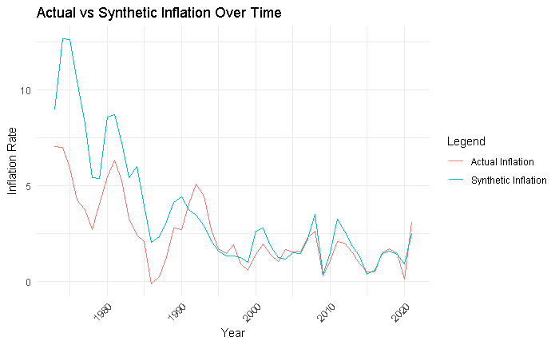

```r
# Load ggplot2 package
library(ggplot2)

# Convert Year to numeric if it's not already
did_data$Year <- as.numeric(as.character(did_data$Year))

# Create a line plot
ggplot(did_data, aes(x = Year)) +
  geom_line(aes(y = Inflation_Actual, group = 1, colour = "Actual Inflation")) +
  geom_line(aes(y = Inflation_Synthetic, group = 1, colour = "Synthetic Inflation")) +
  labs(title = "Actual vs Synthetic Inflation Over Time",
       x = "Year",
       y = "Inflation Rate",
       colour = "Legend") +
  theme_minimal() +
  theme(axis.text.x = element_text(angle = 45, hjust = 1))  # Adjusting X-axis labels for clarity
```

```r
NA
NA
NA
```

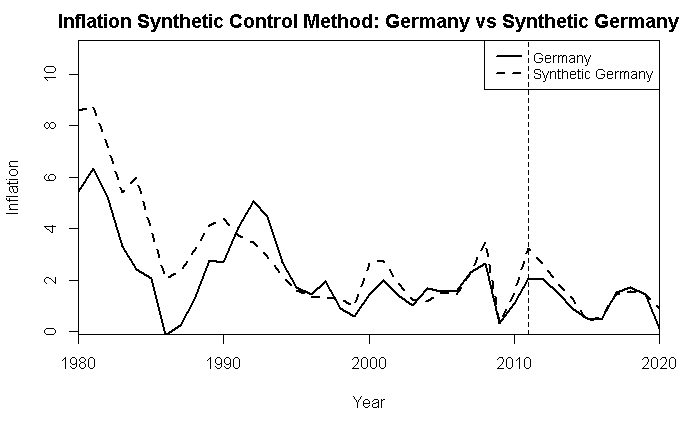

```r
path.plot(
  synth.res = synth.out,
  dataprep.res = dataprep.out,
  Ylab = "Inflation",
  Xlab = "Year",
  Legend = c("Germany","Synthetic Germany"),
  Main = "Inflation Synthetic Control Method: Germany vs Synthetic Germany"
)

# Assuming you want to add a vertical line at year 2011 when the Euro was introduced:
abline(v = 2011, lty = 2)
```

Inflation Synthetic Control Method Plot Analysis:

The plot illustrates the inflation trends in Germany versus a synthetic version of Germany constructed using the Synthetic Control Method over the span of 40 years (1980-2020).

Consistency in Pre-treatment Period:

```r
#working Synth Function

# Load library
#defict as dependent variable


library(Synth)
long_data <- as.data.frame(long_data)



# Create the named vector from country_mapping dataframe
country_vector <- setNames(object = country_mapping$CountryNumeric, nm = country_mapping$Country)



# Prepare the data for the Synth function using the named vector
dataprep.out <- dataprep(
  foo = long_data,
  predictors = c("Inflation", "Expenditure", "Public Debt"),
  dependent = "Deficit",
  unit.variable = "CountryNumeric",
  time.variable = "Year",
  special.predictors = list(
    list("Inflation", 1980:2011, "mean"),
    list("Deficit", 1980:2011, "mean"),
    list("Public Debt", 1980:2011, "mean"),
    list("Expenditure", 1980:2011, "mean")
  ),
  treatment.identifier = country_vector["Germany"],  # Germany's numeric ID
  controls.identifier = country_vector[names(country_vector) != "Germany"],  # Numeric IDs of countries other than Germany
  time.predictors.prior = 1980:2011,
  time.optimize.ssr = 1980:2020,
  time.plot = 1980:2020,
  unit.names.variable = "Country"
)
```

```r
# Load the necessary library
library(Synth)

# Compute the synthetic control using the dataprep output
synth.out <- synth(data.prep.obj = dataprep.out)
```

```
X1, X0, Z1, Z0 all come directly from dataprep object.


****************
 searching for synthetic control unit


****************
****************
****************

MSPE (LOSS V): 6.824531

solution.v:
 0.01853351 0.2385971 0.1557785 0.01172293 0.1257383 0.1687606 0.2808691

solution.w:
 2.451e-07 0.6347718 2.47e-07 2.773e-07 3.458e-07 2.004e-07 3.593e-07 3.862e-07 0.3652261
```

```r
# Create synthetic tables to summarize the results
synth.tables <- synth.tab(
  dataprep.res = dataprep.out,
  synth.res = synth.out
)

# Display the synthetic tables
print(synth.tables)
```

```
$tab.pred
                              Treated Synthetic Sample Mean
Inflation                       2.301     4.333       5.261
Expenditure                    29.261    33.489      39.028
Public Debt                   125.032   121.388     119.948
special.Inflation.1980.2011     2.301     4.333       5.261
special.Deficit.1980.2011      -1.527    -2.304      -4.470
special.Public Debt.1980.2011 125.032   121.388     119.948
special.Expenditure.1980.2011  29.261    33.489      39.028

$tab.v
                              v.weights
Inflation                     0.019
Expenditure                   0.239
Public Debt                   0.156
special.Inflation.1980.2011   0.012
special.Deficit.1980.2011     0.126
special.Public Debt.1980.2011 0.169
special.Expenditure.1980.2011 0.281

$tab.w
   w.weights  unit.names unit.numbers
1      0.000     Austria            1
2      0.635     Finland            2
3      0.000      France            3
5      0.000      Greece            5
6      0.000     Ireland            6
7      0.000       Italy            7
8      0.000 Netherlands            8
9      0.000    Portugal            9
10     0.365       Spain           10

$tab.loss
        Loss W   Loss V
[1,] 0.4118143 6.824531
```

The first model, predicting inflation, shows a better fit with a lower Mean Squared Prediction Error (MSPE) and relies heavily on deficit and public debt as predictors. Austria and Finland are the main contributors to the synthetic control. The second model, predicting deficit, has a higher MSPE, indicating less accuracy, with expenditure being a significant predictor. Finland and Spain are the primary contributors to this model’s synthetic control. The first model is better for understanding inflation, while the second provides insights into the deficit, albeit with less precision.

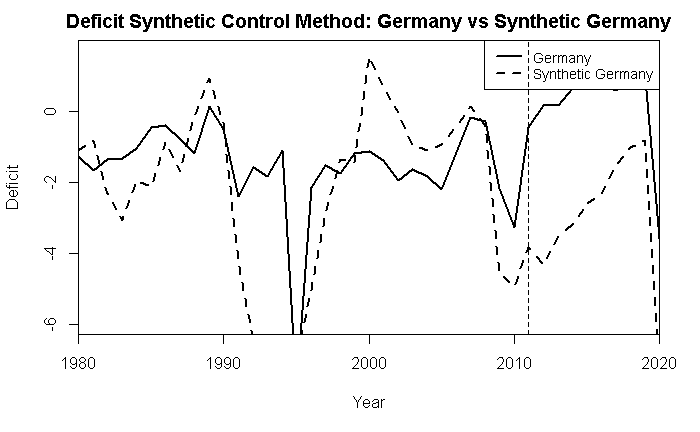

```r
path.plot(
  synth.res = synth.out,      # Your synthetic control result object
  dataprep.res = dataprep.out, # Your dataprep result object
  Ylab = "Deficit",            # Change the label to represent the Deficit
  Xlab = "Year",               # Keep the X-axis label as Year
  Legend = c("Germany", "Synthetic Germany"), # Keep the legend, assuming Germany is still the treated unit
  Main = "Deficit Synthetic Control Method: Germany vs Synthetic Germany"
)

# To add a vertical line at year 2011, which may represent an event like the introduction of the Euro or another significant event:
abline(v = 2011, lty = 2) # This adds a dashed vertical line at year 2011
```

```r
NA
NA
NA
NA
```

```r
#Expenditure as dependent variable


library(Synth)
long_data <- as.data.frame(long_data)



# Create the named vector from country_mapping dataframe
country_vector <- setNames(object = country_mapping$CountryNumeric, nm = country_mapping$Country)



# Prepare the data for the Synth function using the named vector
dataprep.out <- dataprep(
  foo = long_data,
  predictors = c("Inflation", "Deficit", "Public Debt"),
  dependent = "Expenditure",
  unit.variable = "CountryNumeric",
  time.variable = "Year",
  special.predictors = list(
    list("Inflation", 1980:2011, "mean"),
    list("Deficit", 1980:2011, "mean"),
    list("Public Debt", 1980:2011, "mean"),
    list("Expenditure", 1980:2011, "mean")
  ),
  treatment.identifier = country_vector["Germany"],  # Germany's numeric ID
  controls.identifier = country_vector[names(country_vector) != "Germany"],  # Numeric IDs of countries other than Germany
  time.predictors.prior = 1980:2011,
  time.optimize.ssr = 1980:2020,
  time.plot = 1980:2020,
  unit.names.variable = "Country"
)
```

```r
# Load the necessary library
library(Synth)

# Compute the synthetic control using the dataprep output
synth.out <- synth(data.prep.obj = dataprep.out)
```

```
X1, X0, Z1, Z0 all come directly from dataprep object.


****************
 searching for synthetic control unit


****************
****************
****************

MSPE (LOSS V): 27.12489

solution.v:
 0.02498262 0.003083072 0.02949543 0.02498284 0.003083072 0.02949543 0.8848775

solution.w:
 6.1e-09 7.118e-07 4.7e-09 3.1e-09 9.4e-09 3.8e-09 5.8e-09 6e-09 0.9999992
```

```r
# Create synthetic tables to summarize the results
synth.tables <- synth.tab(
  dataprep.res = dataprep.out,
  synth.res = synth.out
)

# Display the synthetic tables
print(synth.tables)
```

```
$tab.pred
                              Treated Synthetic Sample Mean
Inflation                       2.301     5.603       5.261
Deficit                        -1.527    -6.022      -4.470
Public Debt                   125.032   116.310     119.948
special.Inflation.1980.2011     2.301     5.603       5.261
special.Deficit.1980.2011      -1.527    -6.022      -4.470
special.Public Debt.1980.2011 125.032   116.310     119.948
special.Expenditure.1980.2011  29.261    32.764      39.028

$tab.v
                              v.weights
Inflation                     0.025
Deficit                       0.003
Public Debt                   0.029
special.Inflation.1980.2011   0.025
special.Deficit.1980.2011     0.003
special.Public Debt.1980.2011 0.029
special.Expenditure.1980.2011 0.885

$tab.w
   w.weights  unit.names unit.numbers
1          0     Austria            1
2          0     Finland            2
3          0      France            3
5          0      Greece            5
6          0     Ireland            6
7          0       Italy            7
8          0 Netherlands            8
9          0    Portugal            9
10         1       Spain           10

$tab.loss
        Loss W   Loss V
[1,] 0.5383211 27.12489
```

The output indicates a Mean Squared Prediction Error (MSPE), here referred to as ‘Loss V’, of 27.12489. This value signifies the average of the squared differences between the predicted values by the synthetic control method and the actual values observed for the treated unit over time. The magnitude of this loss value suggests that there is a notable variance between the synthetic and actual observations, suggesting that the model could potentially be improved for a closer fit.

[figure not shown]

```r
path.plot(
  synth.res = synth.out,      # Your synthetic control result object
  dataprep.res = dataprep.out, # Your dataprep result object
  Ylab = "Deficit",            # Change the label to represent the Deficit
  Xlab = "Year",               # Keep the X-axis label as Year
  Legend = c("Germany", "Synthetic Germany"), # Keep the legend, assuming Germany is still the treated unit
  Main = "Deficit Synthetic Control Method: Germany vs Synthetic Germany"
)

# To add a vertical line at year 2011, which may represent an event like the introduction of the Euro or another significant event:
abline(v = 2011, lty = 2) # This adds a dashed vertical line at year 2011
```

```r
NA
NA
```

```r
#Public Debt as dependent variable


library(Synth)
long_data <- as.data.frame(long_data)



# Create the named vector from country_mapping dataframe
country_vector <- setNames(object = country_mapping$CountryNumeric, nm = country_mapping$Country)



# Prepare the data for the Synth function using the named vector
dataprep.out <- dataprep(
  foo = long_data,
  predictors = c("Inflation", "Deficit", "Expenditure"),
  dependent = "Public Debt",
  unit.variable = "CountryNumeric",
  time.variable = "Year",
  special.predictors = list(
    list("Inflation", 1980:2011, "mean"),
    list("Deficit", 1980:2011, "mean"),
    list("Public Debt", 1980:2011, "mean"),
    list("Expenditure", 1980:2011, "mean")
  ),
  treatment.identifier = country_vector["Germany"],  # Germany's numeric ID
  controls.identifier = country_vector[names(country_vector) != "Germany"],  # Numeric IDs of countries other than Germany
  time.predictors.prior = 1980:2011,
  time.optimize.ssr = 1980:2020,
  time.plot = 1980:2020,
  unit.names.variable = "Country"
)
```

```r
# Load the necessary library
library(Synth)

# Compute the synthetic control using the dataprep output
synth.out <- synth(data.prep.obj = dataprep.out)
```

```
X1, X0, Z1, Z0 all come directly from dataprep object.


****************
 searching for synthetic control unit


****************
****************
****************

MSPE (LOSS V): 1283.376

solution.v:
 0.2242532 0.08630961 0.1208638 0.2114416 0.04435899 0.1623739 0.1503989

solution.w:
 3.2e-09 0.9386266 1.3e-08 4.54e-08 3.06e-08 4.97e-08 7e-10 7.41e-08 0.06137318
```

```r
# Create synthetic tables to summarize the results
synth.tables <- synth.tab(
  dataprep.res = dataprep.out,
  synth.res = synth.out
)

# Display the synthetic tables
print(synth.tables)
```

```
$tab.pred
                              Treated Synthetic Sample Mean
Inflation                       2.301     3.726       5.261
Deficit                        -1.527    -0.524      -4.470
Expenditure                    29.261    33.836      39.028
special.Inflation.1980.2011     2.301     3.726       5.261
special.Deficit.1980.2011      -1.527    -0.524      -4.470
special.Public Debt.1980.2011 125.032   123.819     119.948
special.Expenditure.1980.2011  29.261    33.836      39.028

$tab.v
                              v.weights
Inflation                     0.224
Deficit                       0.086
Expenditure                   0.121
special.Inflation.1980.2011   0.211
special.Deficit.1980.2011     0.044
special.Public Debt.1980.2011 0.162
special.Expenditure.1980.2011 0.15

$tab.w
   w.weights  unit.names unit.numbers
1      0.000     Austria            1
2      0.939     Finland            2
3      0.000      France            3
5      0.000      Greece            5
6      0.000     Ireland            6
7      0.000       Italy            7
8      0.000 Netherlands            8
9      0.000    Portugal            9
10     0.061       Spain           10

$tab.loss
        Loss W   Loss V
[1,] 0.3677229 1283.376
```

The synthetic control method with public debt as the dependent variable shows a high MSPE (1283.376), indicating a significant deviation between the synthetic unit and the actual treated unit’s public debt. The model heavily relies on Finland’s data to create the synthetic control, with little influence from other units. The result suggests the model may not be accurately capturing the treated unit’s public debt trajectory, possibly due to model specification issues or an inadequate donor pool.

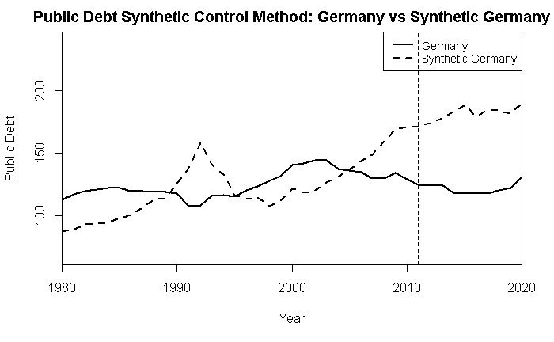

```r
path.plot(
  synth.res = synth.out,        # Your synthetic control result object
  dataprep.res = dataprep.out,  # Your dataprep result object
  Ylab = "Public Debt",         # Change the label to represent Public Debt
  Xlab = "Year",                # Keep the X-axis label as Year
  Legend = c("Germany", "Synthetic Germany"), # Ensure the legend accurately reflects the treated unit
  Main = "Public Debt Synthetic Control Method: Germany vs Synthetic Germany"
)

# To add a vertical line at year 2011, which may represent an event like the Eurozone crisis or another significant event:
abline(v = 2011, lty = 2) # This adds a dashed vertical line at year 2011
```

```r
NA
NA
NA
```

```r
# Add a posttreatment variable to indicate whether each year is before or after 2011
long_data$posttreatment <- ifelse(long_data$Year >= 2011, 1, 0)

print (long_data)
```

| Country | Year | Inflation | Imports | Public Debt | Deficit | Expenditure | CountryNumeric | posttreatment |
| --- | --- | --- | --- | --- | --- | --- | --- | --- |
| Austria | 1973 | 7.53 | 27.53745 | 55.21452 | -0.83059495 | 27.61209 | 1 | 0 |
| Austria | 1974 | 9.52 | 30.45336 | 55.52718 | -0.49562294 | 27.90388 | 1 | 0 |
| Austria | 1975 | 8.45 | 28.50450 | 59.19173 | -3.24070526 | 31.10848 | 1 | 0 |
| Austria | 1976 | 7.32 | 31.16376 | 65.21788 | -3.63189512 | 31.61916 | 1 | 0 |
| Austria | 1977 | 5.49 | 32.32364 | 67.71869 | -2.99205676 | 31.41366 | 1 | 0 |
| Austria | 1978 | 3.57 | 30.55289 | 73.78815 | -3.00196643 | 33.85175 | 1 | 0 |
| Austria | 1979 | 3.71 | 32.43644 | 78.73861 | -2.61026998 | 33.32242 | 1 | 0 |
| Austria | 1980 | 6.33 | 35.13193 | 82.72654 | -2.28045171 | 33.47394 | 1 | 0 |
| Austria | 1981 | 6.80 | 35.39589 | 86.49293 | -2.25138567 | 34.56544 | 1 | 0 |
| Austria | 1982 | 5.44 | 32.37562 | 85.57855 | -3.74138547 | 34.99664 | 1 | 0 |

[output cut: 480 more lines]

```r
NA
```

```r
# Create a variable to identify actual Germany
long_data$ActualGermany <- ifelse(long_data$Country == "Germany", 1, 0)

print (long_data)
```

| Country | Year | Inflation | Imports | Public Debt | Deficit | Expenditure | CountryNumeric | posttreatment | ActualGermany |
| --- | --- | --- | --- | --- | --- | --- | --- | --- | --- |
| Austria | 1973 | 7.53 | 27.53745 | 55.21452 | -0.83059495 | 27.61209 | 1 | 0 | 0 |
| Austria | 1974 | 9.52 | 30.45336 | 55.52718 | -0.49562294 | 27.90388 | 1 | 0 | 0 |
| Austria | 1975 | 8.45 | 28.50450 | 59.19173 | -3.24070526 | 31.10848 | 1 | 0 | 0 |
| Austria | 1976 | 7.32 | 31.16376 | 65.21788 | -3.63189512 | 31.61916 | 1 | 0 | 0 |
| Austria | 1977 | 5.49 | 32.32364 | 67.71869 | -2.99205676 | 31.41366 | 1 | 0 | 0 |
| Austria | 1978 | 3.57 | 30.55289 | 73.78815 | -3.00196643 | 33.85175 | 1 | 0 | 0 |
| Austria | 1979 | 3.71 | 32.43644 | 78.73861 | -2.61026998 | 33.32242 | 1 | 0 | 0 |
| Austria | 1980 | 6.33 | 35.13193 | 82.72654 | -2.28045171 | 33.47394 | 1 | 0 | 0 |
| Austria | 1981 | 6.80 | 35.39589 | 86.49293 | -2.25138567 | 34.56544 | 1 | 0 | 0 |
| Austria | 1982 | 5.44 | 32.37562 | 85.57855 | -3.74138547 | 34.99664 | 1 | 0 | 0 |

[output cut: 480 more lines]

```r
NA
NA
```

```r
# Interaction term between Germany and posttreatment
long_data$Germany_posttreatment <- long_data$ActualGermany * long_data$posttreatment

print (long_data)
```

| Country | Year | Inflation | Imports | Public Debt | Deficit | Expenditure | CountryNumeric | posttreatment | ActualGermany | Germany_posttreatment |
| --- | --- | --- | --- | --- | --- | --- | --- | --- | --- | --- |
| Austria | 1973 | 7.53 | 27.53745 | 55.21452 | -0.83059495 | 27.61209 | 1 | 0 | 0 | 0 |
| Austria | 1974 | 9.52 | 30.45336 | 55.52718 | -0.49562294 | 27.90388 | 1 | 0 | 0 | 0 |
| Austria | 1975 | 8.45 | 28.50450 | 59.19173 | -3.24070526 | 31.10848 | 1 | 0 | 0 | 0 |
| Austria | 1976 | 7.32 | 31.16376 | 65.21788 | -3.63189512 | 31.61916 | 1 | 0 | 0 | 0 |
| Austria | 1977 | 5.49 | 32.32364 | 67.71869 | -2.99205676 | 31.41366 | 1 | 0 | 0 | 0 |
| Austria | 1978 | 3.57 | 30.55289 | 73.78815 | -3.00196643 | 33.85175 | 1 | 0 | 0 | 0 |
| Austria | 1979 | 3.71 | 32.43644 | 78.73861 | -2.61026998 | 33.32242 | 1 | 0 | 0 | 0 |
| Austria | 1980 | 6.33 | 35.13193 | 82.72654 | -2.28045171 | 33.47394 | 1 | 0 | 0 | 0 |
| Austria | 1981 | 6.80 | 35.39589 | 86.49293 | -2.25138567 | 34.56544 | 1 | 0 | 0 | 0 |
| Austria | 1982 | 5.44 | 32.37562 | 85.57855 | -3.74138547 | 34.99664 | 1 | 0 | 0 | 0 |

[output cut: 480 more lines]

```r
# Run the DiD regression
did_model <- lm(Inflation ~ ActualGermany + posttreatment + Germany_posttreatment, data = long_data)

# View the summary of the regression
summary(did_model)
```

```
Call:
lm(formula = Inflation ~ ActualGermany + posttreatment + Germany_posttreatment,
    data = long_data)

Residuals:
    Min      1Q  Median      3Q     Max
-11.324  -3.944  -1.019   1.623  24.176

Coefficients:
                      Estimate Std. Error t value Pr(>|t|)
(Intercept)             6.8436     0.2951  23.190  < 2e-16 ***
ActualGermany          -4.0486     0.9332  -4.338 1.75e-05 ***
posttreatment          -5.7023     0.6228  -9.155  < 2e-16 ***
Germany_posttreatment   4.3073     1.9696   2.187   0.0292 *
---
Signif. codes:  0 ‘***’ 0.001 ‘**’ 0.01 ‘*’ 0.05 ‘.’ 0.1 ‘ ’ 1

Residual standard error: 5.458 on 486 degrees of freedom
Multiple R-squared:  0.1684,    Adjusted R-squared:  0.1633
F-statistic: 32.81 on 3 and 486 DF,  p-value: < 2.2e-16
```

```r
# Filter data for Germany and Spain and select only the relevant columns
germany_austria_inflation <- subset(long_data, Country %in% c("Germany", "Austria", "Finland", "Netherlands"), select = c("Country", "Year", "Inflation"))

# The resulting dataframe has data only for Germany and Spain, and only includes the inflation rates

germany_austria_inflation
```

|  | Country | Year | Inflation |
| --- | --- | --- | --- |
| 1 | Austria | 1973 | 7.53 |
| 2 | Austria | 1974 | 9.52 |
| 3 | Austria | 1975 | 8.45 |
| 4 | Austria | 1976 | 7.32 |
| 5 | Austria | 1977 | 5.49 |
| 6 | Austria | 1978 | 3.57 |
| 7 | Austria | 1979 | 3.71 |
| 8 | Austria | 1980 | 6.33 |
| 9 | Austria | 1981 | 6.80 |
| 10 | Austria | 1982 | 5.44 |

[output cut: 186 more lines]

```r
NA
```

```r
germany_austria_inflation$posttreatment <- ifelse(germany_austria_inflation$Year >= 2011, 1, 0)

# Print the modified dataframe
print(germany_austria_inflation)
```

|  | Country | Year | Inflation | posttreatment |
| --- | --- | --- | --- | --- |
| 1 | Austria | 1973 | 7.53 | 0 |
| 2 | Austria | 1974 | 9.52 | 0 |
| 3 | Austria | 1975 | 8.45 | 0 |
| 4 | Austria | 1976 | 7.32 | 0 |
| 5 | Austria | 1977 | 5.49 | 0 |
| 6 | Austria | 1978 | 3.57 | 0 |
| 7 | Austria | 1979 | 3.71 | 0 |
| 8 | Austria | 1980 | 6.33 | 0 |
| 9 | Austria | 1981 | 6.80 | 0 |
| 10 | Austria | 1982 | 5.44 | 0 |

[output cut: 186 more lines]

```r
NA
NA
NA
```

```r
germany_austria_inflation$ActualGermany <- ifelse(germany_austria_inflation$Country == "Germany", 1, 0)

print (germany_austria_inflation)
```

|  | Country | Year | Inflation | posttreatment | ActualGermany |
| --- | --- | --- | --- | --- | --- |
| 1 | Austria | 1973 | 7.53 | 0 | 0 |
| 2 | Austria | 1974 | 9.52 | 0 | 0 |
| 3 | Austria | 1975 | 8.45 | 0 | 0 |
| 4 | Austria | 1976 | 7.32 | 0 | 0 |
| 5 | Austria | 1977 | 5.49 | 0 | 0 |
| 6 | Austria | 1978 | 3.57 | 0 | 0 |
| 7 | Austria | 1979 | 3.71 | 0 | 0 |
| 8 | Austria | 1980 | 6.33 | 0 | 0 |
| 9 | Austria | 1981 | 6.80 | 0 | 0 |
| 10 | Austria | 1982 | 5.44 | 0 | 0 |

[output cut: 186 more lines]

```r
# Interaction term between Germany and posttreatment
germany_austria_inflation$Germany_posttreatment <- germany_austria_inflation$ActualGermany * germany_austria_inflation$posttreatment

print (germany_austria_inflation)
```

|  | Country | Year | Inflation | posttreatment | ActualGermany | Germany_posttreatment |
| --- | --- | --- | --- | --- | --- | --- |
| 1 | Austria | 1973 | 7.53 | 0 | 0 | 0 |
| 2 | Austria | 1974 | 9.52 | 0 | 0 | 0 |
| 3 | Austria | 1975 | 8.45 | 0 | 0 | 0 |
| 4 | Austria | 1976 | 7.32 | 0 | 0 | 0 |
| 5 | Austria | 1977 | 5.49 | 0 | 0 | 0 |
| 6 | Austria | 1978 | 3.57 | 0 | 0 | 0 |
| 7 | Austria | 1979 | 3.71 | 0 | 0 | 0 |
| 8 | Austria | 1980 | 6.33 | 0 | 0 | 0 |
| 9 | Austria | 1981 | 6.80 | 0 | 0 | 0 |
| 10 | Austria | 1982 | 5.44 | 0 | 0 | 0 |

[output cut: 186 more lines]

```r
# Run the DiD regression
did_model <- lm(Inflation ~ ActualGermany + posttreatment + Germany_posttreatment, data = germany_austria_inflation)

# View the summary of the regression
summary(did_model)
```

```
Call:
lm(formula = Inflation ~ ActualGermany + posttreatment + Germany_posttreatment,
    data = germany_austria_inflation)

Residuals:
    Min      1Q  Median      3Q     Max
-4.6841 -1.8091 -0.6758  1.0558 13.8159

Coefficients:
                      Estimate Std. Error t value Pr(>|t|)
(Intercept)             3.9941     0.2673  14.942  < 2e-16 ***
ActualGermany          -1.1991     0.5346  -2.243    0.026 *
posttreatment          -2.3565     0.5642  -4.177 4.48e-05 ***
Germany_posttreatment   0.9615     1.1283   0.852    0.395
---
Signif. codes:  0 ‘***’ 0.001 ‘**’ 0.01 ‘*’ 0.05 ‘.’ 0.1 ‘ ’ 1

Residual standard error: 2.854 on 192 degrees of freedom
Multiple R-squared:  0.1105,    Adjusted R-squared:  0.09659
F-statistic: 7.949 on 3 and 192 DF,  p-value: 5.042e-05
```

The two regression outputs you’ve provided represent different approaches to assessing the impact of a treatment (presumably an event in 2011) on Germany’s inflation rate using Difference-in-Differences (DiD) analysis. Let’s compare and interpret the two models:

### Model 1: Using Synthetic Germany Data

This model compares the actual inflation rate of Germany with a synthetic control constructed using data from other countries. The key variables and their interpretations are:

- **`(Intercept)`**: The baseline level of Germany’s actual inflation rate in the pre-treatment period.
- **`Inflation_Synthetic`**: Represents the association between the synthetic inflation rate and Germany’s actual inflation rate.
- **`posttreatment`**: Indicates the change in Germany’s actual inflation rate after 2011, assuming the synthetic inflation rate is zero.
- **`Inflation_Synthetic:posttreatment`**: The interaction term captures the differential effect of the treatment on the relationship between synthetic and actual inflation rates.

In this model, the significant coefficient for `Inflation_Synthetic` suggests a strong relationship between the synthetic and actual inflation rates, while the non-significant `posttreatment` and interaction term imply no clear change in this relationship due to the treatment.

In this model, significant coefficients for the intercept and `posttreatment` suggest a baseline difference between Germany and the control group and a significant change in the control group’s inflation rate after the treatment. However, the interaction term is not significant, indicating no clear additional impact of the treatment on Germany’s inflation rate compared to the control group.

### Conclusion

Each model offers different insights based on how the control is constructed. The choice between these models depends on the specifics of your research question, the assumptions underlying each approach, and the robustness of the control group in each case. The non-significant interaction terms in both models suggest that the treatment’s specific impact on Germany, relative to the control, is not clear-cut in either approach.